# textRank

jaume cloquell capo

21 de mayo de 2019

## R Markdown

https://www.hvitfeldt.me/blog/tidy-text-summarization-using-textrank/#data-preparation

We start by loading the appropriate packages, which include tidyverse for general tasks, tidytext for text manipulations, textrank for the implementation of the TextRank algorithm and finally rvest to scrape an article to use as an example. The github for the textrank package can be found here.

```r
library(tidyverse)
library(tidytext)
library(textrank)
library(rvest)
library(tm)
```

next we load the article into a tibble (since tidytext required the input as a data.frame). We start by tokenize according to sentences which is done by setting token = “sentences” in unnest_tokens. The tokenization is not always perfect using this tokenizer, but it have a low number of dependencies and is sufficient for this showcase. Lastly we add sentence number column and switch the order of the columns (textrank_sentences prefers the columns in a certain order).

```r
article_sentences <- tibble(text = article) %>%
  unnest_tokens(sentence, text, token = "sentences") %>%
  mutate(sentence_id = row_number()) %>%
  select(sentence_id, sentence)
```

next we will tokenize again but this time to get words. In doing this we will retain the sentence_id column in our data.

```r
article_words <- article_sentences %>%
  unnest_tokens(word, sentence)
article_words
```

```
## # A tibble: 817 x 2
##    sentence_id word
##          <int> <chr>
##  1           1 xiii
##  2           1 legislatura
##  3           2 meritxell
##  4           2 batet
##  5           2 elegida
##  6           2 nueva
##  7           2 presidenta
##  8           2 del
##  9           2 congreso
## 10           2 de
## # … with 807 more rows
```

```r
article_words %>%
  count(word, sort = TRUE)
```

```
## # A tibble: 362 x 2
##    word      n
##    <chr> <int>
##  1 de       49
##  2 la       34
##  3 que      26
##  4 y        25
##  5 los      23
##  6 ha       22
##  7 a        17
##  8 del      17
##  9 el       17
## 10 en       17
## # … with 352 more rows
```

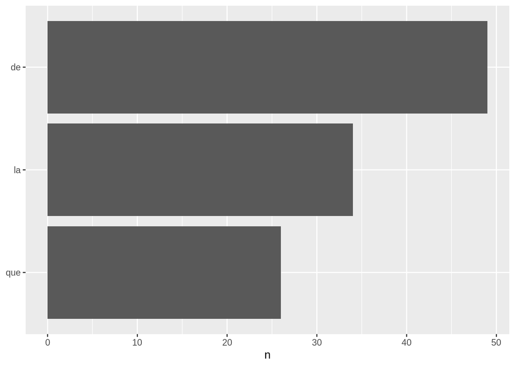

```r
library(ggplot2)

article_words %>%
  count(word, sort = TRUE) %>%
  filter(n > 25) %>%
  mutate(word = reorder(word, n)) %>%
  ggplot(aes(word, n)) +
  geom_col() +
  xlab(NULL) +
  coord_flip()
```

```r
stopwords(kind = "es")
```

```
##   [1] "de"           "la"           "que"          "el"
##   [5] "en"           "y"            "a"            "los"
##   [9] "del"          "se"           "las"          "por"
##  [13] "un"           "para"         "con"          "no"
##  [17] "una"          "su"           "al"           "lo"
##  [21] "como"         "más"          "pero"         "sus"
##  [25] "le"           "ya"           "o"            "este"
##  [29] "sí"           "porque"       "esta"         "entre"
##  [33] "cuando"       "muy"          "sin"          "sobre"
##  [37] "también"      "me"           "hasta"        "hay"
##  [41] "donde"        "quien"        "desde"        "todo"
##  [45] "nos"          "durante"      "todos"        "uno"
##  [49] "les"          "ni"           "contra"       "otros"
##  [53] "ese"          "eso"          "ante"         "ellos"
##  [57] "e"            "esto"         "mí"           "antes"
```

[output cut: 62 more lines]

```r
article_words <- article_words %>%
  anti_join(stop_words, by = "word")
article_words
```

```
## # A tibble: 736 x 2
##    sentence_id word
##          <int> <chr>
##  1           1 xiii
##  2           1 legislatura
##  3           2 meritxell
##  4           2 batet
##  5           2 elegida
##  6           2 nueva
##  7           2 presidenta
##  8           2 del
##  9           2 congreso
## 10           2 de
## # … with 726 more rows
```

```r
article_summary <- textrank_sentences(data = article_sentences,
                                      terminology = article_words)
article_summary
```

```
## Textrank on sentences, showing top 5 most important sentences found:
##   1. ahora entendemos por qué los golpistas querían una presidenta del congreso como ésta y un presidente del gobierno como pedro sánchez que les dejan las manos libres", ha añadido.tanto pp como cs han exigido a la presidenta de la cámara que reúna de inmediato la mesa del congreso para proceder…
##   2. desde el compromiso republicano, como preso político y por imperativo legal, sí prometo", ha sido el acatamiento de oriol junqueras.vista general del hemiciclo de la cámara baja.javier lizón pp y cs lamentan el "espectáculo deplorable"pablo casado, líder del pp, y albert rivera, de cs, se ha…
##   3. la presidenta del congreso ha considerado, no obstante, ante las protestas expresadas formalmente por el líder de cs, albert rivera, que las fórmulas han sido válidas aun cuando muchas de ellas no ha podido oírlas.
##   4. batet ha dado por hecho que todos los parlamentarios han prometido la carta magna acomodándose a los términos que prevé el tribunal constitucional.sin embargo, las fórmulas que han empleado los diputados independentistas para perfeccionar su condición de representantes de una soberanía nacio…
##   5. "con lealtad al mandato democrático del 1 de octubre y al pueblo catalán, por la libertad de los presos y exiliados, por imperativo legal, prometo", ha sido otra de las modalidades."
```